# Detección GBM - analisis de los factores de riesgo

## Limitación de variables a 12 meses

Ya que se va a realizar el análisis a los 12 meses, se limitan las variables a este intervalo.

```r
summary(dataset_images_merge_red$life_expectancy)
```

```
   Min. 1st Qu.  Median    Mean 3rd Qu.    Max.    NA's
    1.0   220.5   362.0   398.1   576.8   958.0      15
```

```r
dataset_images_merge_red[which(dataset_images_merge_red$life_expectancy > 365, arr.ind = TRUE), names(dataset_images_merge_red) == 'life_expectancy'] <- NA
summary(dataset_images_merge_red$life_expectancy)
```

```
   Min. 1st Qu.  Median    Mean 3rd Qu.    Max.    NA's
    1.0    91.0   229.0   202.4   290.8   363.0      31
```

```r
summary(dataset_images_merge_red$time_monitored)
```

```
   Min. 1st Qu.  Median    Mean 3rd Qu.    Max.    NA's
    1.0   220.2   364.0   432.9   661.0  1072.0       3
```

```r
dataset_images_merge_red[which(dataset_images_merge_red$time_monitored > 365, arr.ind = TRUE), names(dataset_images_merge_red) == 'time_monitored'] <- 365
summary(dataset_images_merge_red$time_monitored)
```

```
   Min. 1st Qu.  Median    Mean 3rd Qu.    Max.    NA's
    1.0   220.2   364.0   280.4   365.0   365.0       3
```

## Eliminación de pacientes sin metadatos

Se van a eliminar los pacientes detectados sin metadatos.

```r
dim(dataset_images_merge_red)
```

```
[1] 49 67
```

```r
dataset_images_merge_red <- dataset_images_merge_red[!is.na(dataset_images_merge_red$age),]
dim(dataset_images_merge_red)
```

```
[1] 48 67
```

## Eliminación de variables altamente correladas

Se van a eliminar las variables altamente correlacionadas del dataset para evitar problemas de multicolinealidad y overfitting.

```r
set.seed(173)
case_id_index <- which(names(dataset_images_merge_red) == 'case_id', arr.ind = TRUE)
dim(dataset_images_merge_red)
```

```
[1] 48 67
```

```r
# Buscar atributos altamente correlados
cutoff <- 0.75
highlyCorrelated <- findCorrelation(correlation_numeric_vars_initial, cutoff=cutoff)

# Crear un nuevo dataset sin las variables altamente correladas
dataset_images_merge_red_num <- dataset_images_merge_red[,numeric_var_indexes]
dataset_images_12month_features_num <- dataset_images_merge_red_num[,-highlyCorrelated]

dim(dataset_images_12month_features_num)
```

```
[1] 48 27
```

```r
# Volver a introducir variables no numéricas
dataset_images_12month_features <- as.data.frame(cbind(dataset_images_12month_features_num, life_expectancy = dataset_images_merge_red[,life_expectancy_index], dataset_images_merge_red[,non_numeric_var_indexes_all]))

cause_of_death_index <- which(names(dataset_images_12month_features) == 'cause_of_death_at_12months_follow_up', arr.ind = TRUE)
vital_status_index <- which(names(dataset_images_12month_features) == 'vital_status_at_12months_follow_up', arr.ind = TRUE)
life_expectancy_index <- which(names(dataset_images_12month_features) == 'life_expectancy', arr.ind = TRUE)
```

- Se han eliminado un total de 31 variables correladas.

Por cada variable de clase se crea un dataset distinto con el objetivo de analizarlas por separado.

## Análisis del estado del paciente (vivo/muerto)

Se analiza los valores de las variables dependiendo del estado del paciente, si está vivo o muerto, y la relación que tienen con la variable de clase.

```r
dataset_vital_status <- dataset_images_12month_features[, -c(life_expectancy_index, cause_of_death_index)]

class_val_index <- which(names(dataset_vital_status) == 'vital_status_at_12months_follow_up', arr.ind = TRUE)
numeric_var_indexes_vital <- c(which(sapply(dataset_vital_status, class) == 'numeric', arr.ind = TRUE), which(sapply(dataset_vital_status, class) == 'integer', arr.ind = TRUE))
non_numeric_var_indexes_vital <- which(sapply(dataset_vital_status, class) == 'factor', arr.ind = TRUE)
non_numeric_var_indexes_vital <- non_numeric_var_indexes_vital[-which(non_numeric_var_indexes_vital ==  class_val_index, arr.ind = TRUE)]

summary(dataset_vital_status)
```

```
      bmi        number_of_pack_years_smoked tumor_size_in_cm years_high_alcohol_quantity_consumed time_monitored
 Min.   :19.00   Min.   : 0.000              Min.   :1.000    Min.   : 0.000                       Min.   :  1.0
 1st Qu.:23.11   1st Qu.: 0.000              1st Qu.:2.850    1st Qu.: 0.000                       1st Qu.:220.2
 Median :25.04   Median : 0.000              Median :4.000    Median : 0.000                       Median :364.0
 Mean   :26.67   Mean   :11.406              Mean   :4.055    Mean   : 1.667                       Mean   :280.4
 3rd Qu.:30.03   3rd Qu.: 8.075              3rd Qu.:5.000    3rd Qu.: 0.000                       3rd Qu.:365.0
 Max.   :46.97   Max.   :66.000              Max.   :7.000    Max.   :30.000                       Max.   :365.0
                 NA's   :14                  NA's   :1        NA's   :18                           NA's   :2
  tumor_volume     tumor_dist_x      tumor_dist_y      tumor_compactness   tumor_ent      tumor_smoothness
 Min.   :     0   Min.   :-100.09   Min.   :-128.059   Min.   :0.09626   Min.   : 8.562   Min.   :0.9994
 1st Qu.:  3411   1st Qu.: -18.34   1st Qu.: -59.041   1st Qu.:0.26286   1st Qu.:10.867   1st Qu.:1.0000
 Median : 14300   Median :  16.65   Median : -16.017   Median :0.36947   Median :11.887   Median :1.0000
 Mean   : 24337   Mean   :  13.69   Mean   :  -4.486   Mean   :0.40241   Mean   :11.659   Mean   :1.0000
 3rd Qu.: 34482   3rd Qu.:  47.48   3rd Qu.:  38.640   3rd Qu.:0.58685   3rd Qu.:12.562   3rd Qu.:1.0000
 Max.   :135742   Max.   : 122.91   Max.   : 190.623   Max.   :0.82541   Max.   :13.796   Max.   :1.0000

 tumor_glcm_contrast   tumor_Hu_1          tumor_Hu_2          tumor_Hu_3          tumor_Hu_6          edema_volume
 Min.   :   0.3759   Min.   :5.404e-05   Min.   :7.180e-11   Min.   :3.000e-16   Min.   :-2.750e-15   Min.   :     0
 1st Qu.:   3.9763   1st Qu.:9.200e-05   1st Qu.:5.093e-10   1st Qu.:2.200e-14   1st Qu.: 0.000e+00   1st Qu.: 14742
 Median : 247.3429   Median :1.203e-04   Median :2.523e-09   Median :1.476e-13   Median : 3.000e-20   Median : 52737
 Mean   : 542.3807   Mean   :1.695e-04   Mean   :2.913e-08   Mean   :1.521e-11   Mean   : 3.383e-15   Mean   : 71405
 3rd Qu.: 795.7113   3rd Qu.:1.831e-04   3rd Qu.:7.164e-09   3rd Qu.:6.292e-13   3rd Qu.: 1.470e-18   3rd Qu.:104350
 Max.   :2742.4423   Max.   :1.075e-03   Max.   :9.382e-07   Max.   :6.505e-10   Max.   : 1.646e-13   Max.   :258599

  edema_dist_x        edema_dist_y       edema_compactness     edema_kur         edema_smoothness edema_glcm_contrast
 Min.   :-99999.00   Min.   :-99999.00   Min.   :-99999.00   Min.   :-99999.00   Min.   :-99999   Min.   :-99999.00
 1st Qu.:   -37.98   1st Qu.:   -38.93   1st Qu.:     0.41   1st Qu.:    12.13   1st Qu.:     1   1st Qu.:     3.38
 Median :     3.10   Median :    -5.34   Median :     0.55   Median :    25.68   Median :     1   Median :   546.96
 Mean   : -2081.77   Mean   : -2081.39   Mean   : -2082.78   Mean   : -2038.94   Mean   : -2082   Mean   : -1126.93
 3rd Qu.:    48.48   3rd Qu.:    49.91   3rd Qu.:     0.64   3rd Qu.:    55.15   3rd Qu.:     1   3rd Qu.:  1496.40
 Max.   :    91.32   Max.   :   101.80   Max.   :     0.82   Max.   :   262.95   Max.   :     1   Max.   :  4796.49

 edema_glcm_correlation   edema_Hu_3          age         height_in_cm        case_id
 Min.   :-99999.00      Min.   :-99999   Min.   :39.00   Min.   :150.0   C3L-00016: 1
 1st Qu.:     0.40      1st Qu.:     0   1st Qu.:56.25   1st Qu.:167.5   C3L-00019: 1
 Median :     0.44      Median :     0   Median :62.00   Median :175.0   C3L-00265: 1
 Mean   : -2082.86      Mean   : -2083   Mean   :61.50   Mean   :173.7   C3L-00278: 1
 3rd Qu.:     0.59      3rd Qu.:     0   3rd Qu.:68.25   3rd Qu.:180.0   C3L-00349: 1
 Max.   :     0.70      Max.   :     0   Max.   :88.00   Max.   :198.0   C3L-00424: 1
                                                                         (Other)  :42
                                                                                               alcohol_consumption
 Alcohol consumption equal to or less than 2 drinks per day for men and 1 drink or less per day for women:15
 Alcohol consumption more than 2 drinks per day for men and more than 1 drink per day for women          : 2
 Consumed alcohol in the past, but currently a non-drinker                                               : 3
 Lifelong non-drinker                                                                                    :13
 NA's                                                                                                    :15


    gender                                                       tobacco_smoking_history tumor_mri_type  edema_mri_type
 Female:13   Current reformed smoker within past 15 years                    : 2         AX T1C :38     AX FLAIR:31
 Male  :35   Current reformed smoker, more than 15 years                     : 3         COR T1C: 7     AX T2   :14
             Current smoker: Includes daily and non-daily smokers            : 9         SAG T1C: 3     COR T2  : 2
             Lifelong non-smoker: Less than 100 cigarettes smoked in lifetime:23                        SAG T2  : 1
             NA's                                                            :11


 vital_status_at_12months_follow_up
 Deceased:21
 Living  :27
```

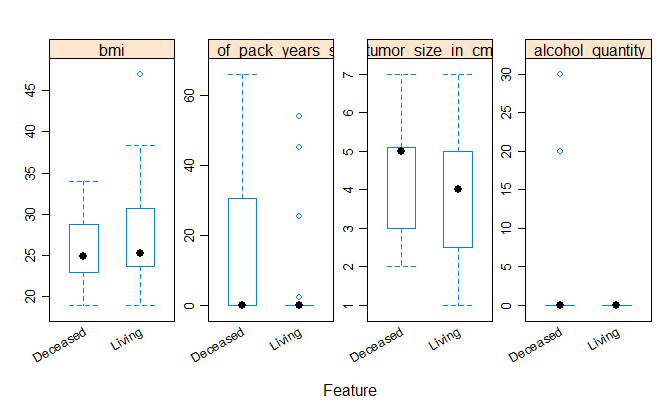

```r
# Boxplots para las variables numéricas
featurePlot(x=dataset_vital_status[, numeric_var_indexes_vital[1:4]],
            y=dataset_vital_status$vital_status_at_12months_follow_up, plot="box",
            scales = list(y = list(relation="free"),
                          x = list(rot = 30)),
            layout = c(4, 1))
```

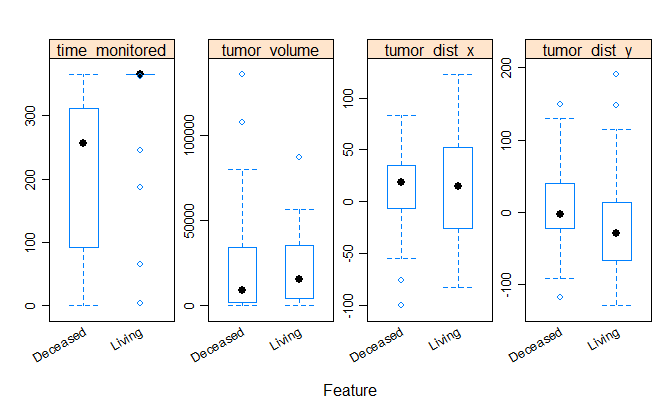

```r
featurePlot(x=dataset_vital_status[, numeric_var_indexes_vital[5:8]],
            y=dataset_vital_status$vital_status_at_12months_follow_up, plot="box",
            scales = list(y = list(relation="free"),
                          x = list(rot = 30)),
            layout = c(4, 1))
```

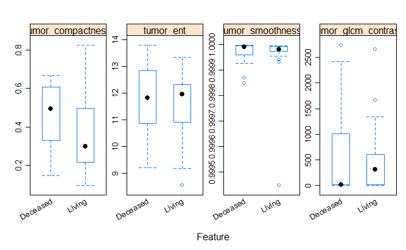

```r
featurePlot(x=dataset_vital_status[, numeric_var_indexes_vital[9:12]],
            y=dataset_vital_status$vital_status_at_12months_follow_up, plot="box",
            scales = list(y = list(relation="free"),
                          x = list(rot = 30)),
            layout = c(4, 1))
```

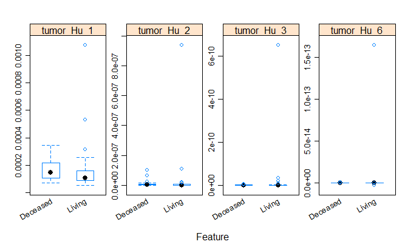

```r
featurePlot(x=dataset_vital_status[, numeric_var_indexes_vital[13:16]],
            y=dataset_vital_status$vital_status_at_12months_follow_up, plot="box",
            scales = list(y = list(relation="free"),
                          x = list(rot = 30)),
            layout = c(4, 1))
```

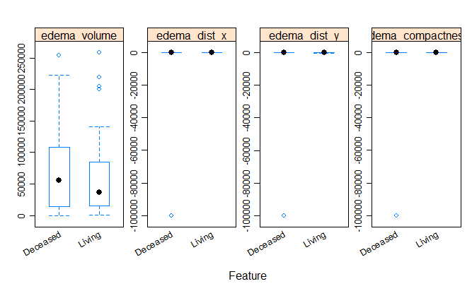

```r
featurePlot(x=dataset_vital_status[, numeric_var_indexes_vital[17:20]],
            y=dataset_vital_status$vital_status_at_12months_follow_up, plot="box",
            scales = list(y = list(relation="free"),
                          x = list(rot = 30)),
            layout = c(4, 1))
```

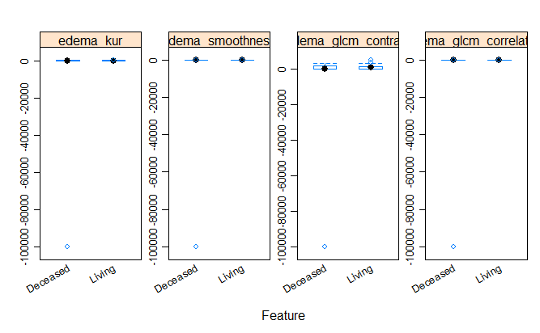

```r
featurePlot(x=dataset_vital_status[, numeric_var_indexes_vital[21:24]],
            y=dataset_vital_status$vital_status_at_12months_follow_up, plot="box",
            scales = list(y = list(relation="free"),
                          x = list(rot = 30)),
            layout = c(4, 1))
```

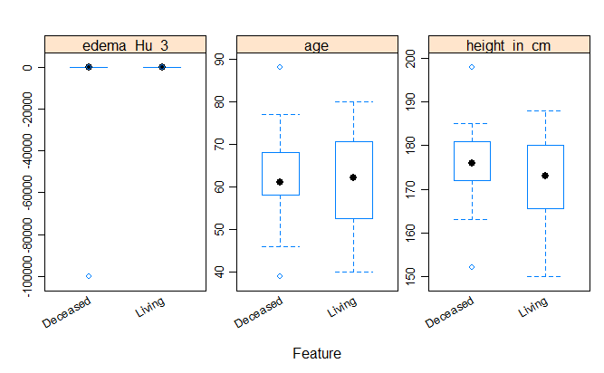

```r
featurePlot(x=dataset_vital_status[, numeric_var_indexes_vital[25:27]],
            y=dataset_vital_status$vital_status_at_12months_follow_up, plot="box",
            scales = list(y = list(relation="free"),
                          x = list(rot = 30)),
            layout = c(3, 1))
```

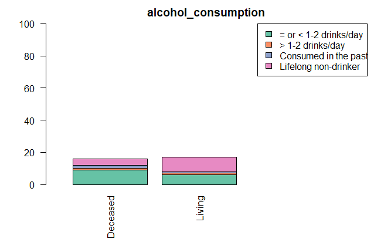

```r
#Barplots
barplot(table(dataset_vital_status[, c(non_numeric_var_indexes_vital[2], class_val_index)]),
        main = names(dataset_vital_status)[non_numeric_var_indexes_vital[2]],
        col = brewer.pal(n = 4, name = "Set2"),
        las = 2,
        xlim = c(0, 4),
        ylim = c(0, 100),
        legend.text = TRUE,
        args.legend = list(x = "topright",
                           legend = c("= or < 1-2 drinks/day",
                                      "> 1-2 drinks/day", "Consumed in the past", "Lifelong non-drinker"),
                           fill = brewer.pal(n = 4, name = "Set2"),
                           ncol = 1))
```

```
minimal value for n is 3, returning requested palette with 3 different levels
```

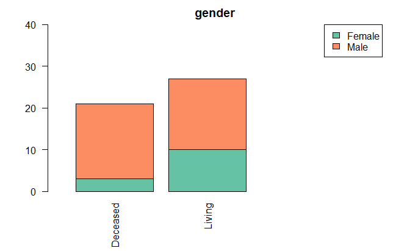

```r
barplot(table(dataset_vital_status[, c(non_numeric_var_indexes_vital[3], class_val_index)]),
        main = names(dataset_vital_status)[non_numeric_var_indexes_vital[3]],
        col = brewer.pal(n = 2, name = "Set2"),
        las = 2,
        xlim = c(0, 4),
        ylim = c(0, 40),
        legend.text = TRUE,
        args.legend = list(x = "topright",
                           legend = c("Female", "Male"),
                           fill = brewer.pal(n = 2, name = "Set2"),
                           ncol = 1))
```

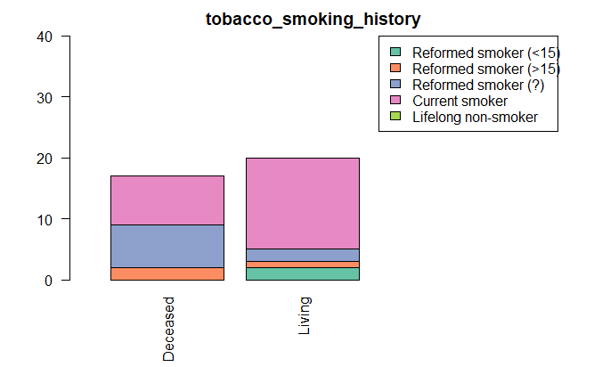

```r
barplot(table(dataset_vital_status[, c(non_numeric_var_indexes_vital[4], class_val_index)]),
        main = names(dataset_vital_status)[non_numeric_var_indexes_vital[4]],
        col = brewer.pal(n = 5, name = "Set2"),
        las = 2,
        xlim = c(0, 4),
        ylim = c(0, 40),
        legend.text = TRUE,
        args.legend = list(x = "topright",
                           legend = c("Reformed smoker (<15)", "Reformed smoker (>15)", "Reformed smoker (?)",
                                      "Current smoker", "Lifelong non-smoker"),
                           fill = brewer.pal(n = 5, name = "Set2"),
                           ncol = 1))
```

```r
# Class imbalance
cbind(Label_freq=table(dataset_vital_status$vital_status_at_12months_follow_up), Label_percent=prop.table(table(dataset_vital_status$vital_status_at_12months_follow_up))*100)
```

```
         Label_freq Label_percent
Deceased         21         43.75
Living           27         56.25
```

Con los datos obtenidos se concluyen los siguientes puntos.

- Se observa que el dataset está más o menos balanceado (43.75% de pacientes muertos y 56.25% vivos).
- Analizando los boxplots y los barplots creados, no se puede determinar una separación clara entre las distintas variables de clase. La realidad es que hay ciertas tendencias, por ejemplo, parece que la mayoría de los que han muerto tenían un tamaño de tumor y de edema algo más alto como mediana. También se han observado ciertas variaciones en la distancia en el eje Y desde el centroide del cerebro al centroide del tumor, el contraste de la matriz de coocurrencia del tumor y en la compacidad del tumor. Pero no se observa que ninguna variable sea determinante para una predicción clara del estado del paciente. También parece que los que nunca han fumado tienden a sobrevivir.

# Análisis de la causa de muerte

Se analiza la causa de la muerte siendo en su mayoría por GBM, aunque aparecen otras posibles causas. Además, hay que tener un cuenta que casi el 60% de los pacientes siguen vivos.

```r
dataset_cause <- dataset_images_12month_features
dataset_cause <- dataset_cause[which(dataset_cause$vital_status_at_12months_follow_up == 'Deceased', arr.ind = TRUE), ]

dataset_cause <- dataset_cause[, -c(life_expectancy_index, vital_status_index)]
class_val_index <- which(names(dataset_cause) == 'cause_of_death_at_12months_follow_up', arr.ind = TRUE)
numeric_var_indexes_cause <- c(which(sapply(dataset_cause, class) == 'numeric', arr.ind = TRUE), which(sapply(dataset_cause, class) == 'integer', arr.ind = TRUE))
non_numeric_var_indexes_cause <- which(sapply(dataset_cause, class) == 'factor', arr.ind = TRUE)
non_numeric_var_indexes_cause <- non_numeric_var_indexes_cause[-which(non_numeric_var_indexes_cause ==  class_val_index, arr.ind = TRUE)]
dataset_cause <- droplevels(dataset_cause)

summary(dataset_cause)
```

```
      bmi        number_of_pack_years_smoked tumor_size_in_cm years_high_alcohol_quantity_consumed time_monitored
 Min.   :19.00   Min.   : 0.00               Min.   :2.000    Min.   : 0.000                       Min.   :  1.0
 1st Qu.:23.01   1st Qu.: 0.00               1st Qu.:3.000    1st Qu.: 0.000                       1st Qu.: 93.0
 Median :24.89   Median : 0.00               Median :5.000    Median : 0.000                       Median :255.5
 Mean   :25.69   Mean   :17.40               Mean   :4.348    Mean   : 3.333                       Mean   :218.7
 3rd Qu.:28.81   3rd Qu.:30.65               3rd Qu.:5.100    3rd Qu.: 0.000                       3rd Qu.:302.8
 Max.   :34.00   Max.   :66.00               Max.   :7.000    Max.   :30.000                       Max.   :365.0
                 NA's   :6                                    NA's   :6                            NA's   :1
  tumor_volume     tumor_dist_x       tumor_dist_y      tumor_compactness   tumor_ent      tumor_smoothness
 Min.   :     0   Min.   :-100.092   Min.   :-117.602   Min.   :0.1471    Min.   : 9.207   Min.   :0.9998
 1st Qu.:  1610   1st Qu.:  -7.014   1st Qu.: -22.064   1st Qu.:0.3285    1st Qu.:10.867   1st Qu.:1.0000
 Median :  8800   Median :  18.236   Median :  -2.548   Median :0.4925    Median :11.824   Median :1.0000
 Mean   : 27704   Mean   :   9.105   Mean   :   6.075   Mean   :0.4476    Mean   :11.732   Mean   :1.0000
 3rd Qu.: 33758   3rd Qu.:  34.607   3rd Qu.:  40.387   3rd Qu.:0.6063    3rd Qu.:12.834   3rd Qu.:1.0000
 Max.   :135742   Max.   :  83.471   Max.   : 148.925   Max.   :0.6682    Max.   :13.796   Max.   :1.0000

 tumor_glcm_contrast   tumor_Hu_1          tumor_Hu_2          tumor_Hu_3          tumor_Hu_6          edema_volume
 Min.   :   0.5663   Min.   :6.975e-05   Min.   :8.577e-11   Min.   :5.691e-15   Min.   :-4.642e-17   Min.   :     0
 1st Qu.:   3.4706   1st Qu.:1.046e-04   1st Qu.:1.365e-09   1st Qu.:2.087e-14   1st Qu.:-5.400e-21   1st Qu.: 14473
 Median :   6.9448   Median :1.458e-04   Median :4.761e-09   Median :2.583e-13   Median : 8.200e-20   Median : 55630
 Mean   : 609.0912   Mean   :1.607e-04   Mean   :1.286e-08   Mean   :7.969e-13   Mean   : 2.968e-17   Mean   : 73574
 3rd Qu.:1011.7682   3rd Qu.:2.160e-04   3rd Qu.:8.888e-09   3rd Qu.:9.684e-13   3rd Qu.: 4.975e-18   3rd Qu.:107946
 Max.   :2742.4423   Max.   :3.463e-04   Max.   :1.024e-07   Max.   :4.732e-12   Max.   : 3.312e-16   Max.   :254130

  edema_dist_x        edema_dist_y       edema_compactness     edema_kur         edema_smoothness edema_glcm_contrast
 Min.   :-99999.00   Min.   :-99999.00   Min.   :-99999.00   Min.   :-99999.00   Min.   :-99999   Min.   :-99999.00
 1st Qu.:   -47.01   1st Qu.:   -43.61   1st Qu.:     0.47   1st Qu.:    11.10   1st Qu.:     1   1st Qu.:     1.27
 Median :   -12.09   Median :     8.32   Median :     0.58   Median :    24.05   Median :     1   Median :     9.06
 Mean   : -4766.39   Mean   : -4748.08   Mean   : -4761.30   Mean   : -4727.56   Mean   : -4761   Mean   : -3900.35
 3rd Qu.:    29.77   3rd Qu.:    61.17   3rd Qu.:     0.67   3rd Qu.:    48.79   3rd Qu.:     1   3rd Qu.:  1563.21
 Max.   :    91.32   Max.   :   101.70   Max.   :     0.82   Max.   :    97.44   Max.   :     1   Max.   :  2987.61

 edema_glcm_correlation   edema_Hu_3          age         height_in_cm        case_id
 Min.   :-99999.00      Min.   :-99999   Min.   :39.00   Min.   :152.0   C3L-00016: 1
 1st Qu.:     0.41      1st Qu.:     0   1st Qu.:58.00   1st Qu.:172.0   C3L-00265: 1
 Median :     0.43      Median :     0   Median :61.00   Median :176.0   C3L-00506: 1
 Mean   : -4761.39      Mean   : -4762   Mean   :61.71   Mean   :175.9   C3L-00528: 1
 3rd Qu.:     0.61      3rd Qu.:     0   3rd Qu.:68.00   3rd Qu.:181.0   C3L-00591: 1
 Max.   :     0.70      Max.   :     0   Max.   :88.00   Max.   :198.0   C3L-00671: 1
                                                                         (Other)  :15
                                                                                               alcohol_consumption
 Alcohol consumption equal to or less than 2 drinks per day for men and 1 drink or less per day for women:9
 Alcohol consumption more than 2 drinks per day for men and more than 1 drink per day for women          :1
 Consumed alcohol in the past, but currently a non-drinker                                               :2
 Lifelong non-drinker                                                                                    :4
 NA's                                                                                                    :5


    gender                                                       tobacco_smoking_history tumor_mri_type  edema_mri_type
 Female: 3   Current reformed smoker, more than 15 years                     :2          AX T1C :17     AX FLAIR:11
 Male  :18   Current smoker: Includes daily and non-daily smokers            :7          COR T1C: 2     AX T2   : 8
             Lifelong non-smoker: Less than 100 cigarettes smoked in lifetime:8          SAG T1C: 2     COR T2  : 1
             NA's                                                            :4                         SAG T2  : 1



       cause_of_death_at_12months_follow_up
 GBM                     :15
 Malignant Brain Neoplasm: 5
 Postoperative oedema    : 1
```

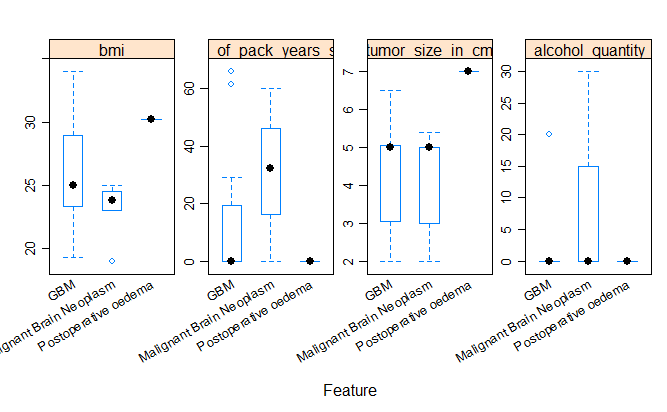

```r
# Boxplots for numeric variables
featurePlot(x=dataset_cause[, numeric_var_indexes_cause[1:4]],
            y=dataset_cause$cause_of_death_at_12months_follow_up, plot="box",
            scales = list(y = list(relation="free"),
                          x = list(rot = 30)),
            layout = c(4, 1))
```

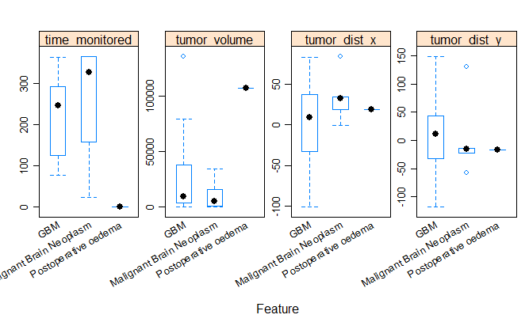

```r
featurePlot(x=dataset_cause[, numeric_var_indexes_cause[5:8]],
            y=dataset_cause$cause_of_death_at_12months_follow_up, plot="box",
            scales = list(y = list(relation="free"),
                          x = list(rot = 30)),
            layout = c(4, 1))
```

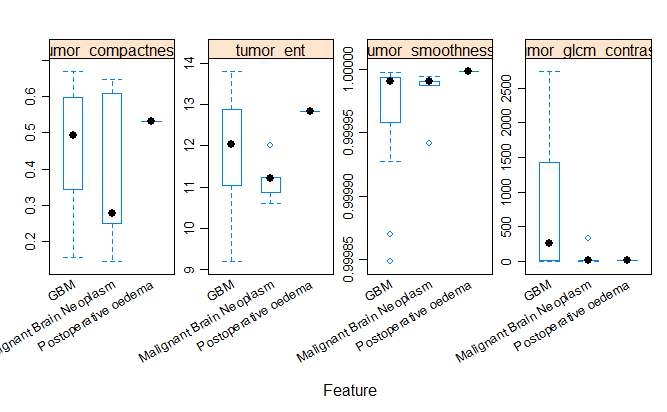

```r
featurePlot(x=dataset_cause[, numeric_var_indexes_cause[9:12]],
            y=dataset_cause$cause_of_death_at_12months_follow_up, plot="box",
            scales = list(y = list(relation="free"),
                          x = list(rot = 30)),
            layout = c(4, 1))
```